# pro

```python
import numpy as np
import pandas as pd
import matplotlib.pyplot as plt
import seaborn as sns

from scipy.stats import norm
from scipy.stats import binom
```

### 1.Import the dataset and do data analysis steps

-like checking the structure & characteristics of the dataset

```python
df=pd.read_csv("aerofit.csv")
```

To get top 5 rows of dataset using head() function

```python
df.head()
```

|  | Product | Age | Gender | Education | MaritalStatus | Usage | Fitness | Income | Miles |
| --- | --- | --- | --- | --- | --- | --- | --- | --- | --- |
| 0 | KP281 | 18 | Male | 14 | Single | 3 | 4 | 29562 | 112 |
| 1 | KP281 | 19 | Male | 15 | Single | 2 | 3 | 31836 | 75 |
| 2 | KP281 | 19 | Female | 14 | Partnered | 4 | 3 | 30699 | 66 |
| 3 | KP281 | 19 | Male | 12 | Single | 3 | 3 | 32973 | 85 |
| 4 | KP281 | 20 | Male | 13 | Partnered | 4 | 2 | 35247 | 47 |

To get last 5 rows of dataset using tail() function

```python
df.tail()
```

|  | Product | Age | Gender | Education | MaritalStatus | Usage | Fitness | Income | Miles |
| --- | --- | --- | --- | --- | --- | --- | --- | --- | --- |
| 175 | KP781 | 40 | Male | 21 | Single | 6 | 5 | 83416 | 200 |
| 176 | KP781 | 42 | Male | 18 | Single | 5 | 4 | 89641 | 200 |
| 177 | KP781 | 45 | Male | 16 | Single | 5 | 5 | 90886 | 160 |
| 178 | KP781 | 47 | Male | 18 | Partnered | 4 | 5 | 104581 | 120 |
| 179 | KP781 | 48 | Male | 18 | Partnered | 4 | 5 | 95508 | 180 |

To get shape of the dataset - rows and columns in dataset using shape method

```python
df.shape
```

```
(180, 9)
```

To get columns names of the aerofit dataset using keys() method

```python
df.keys()
```

```
Index(['Product', 'Age', 'Gender', 'Education', 'MaritalStatus', 'Usage',
       'Fitness', 'Income', 'Miles'],
      dtype='object')
```

### Preperation of data

To get more info about data such as datatype of each column,count of non null values in each column,range of entries - using info() method

```python
df.info()
```

```
<class 'pandas.core.frame.DataFrame'>
RangeIndex: 180 entries, 0 to 179
Data columns (total 9 columns):
 #   Column         Non-Null Count  Dtype
---  ------         --------------  -----
 0   Product        180 non-null    object
 1   Age            180 non-null    int64
 2   Gender         180 non-null    object
 3   Education      180 non-null    int64
 4   MaritalStatus  180 non-null    object
 5   Usage          180 non-null    int64
 6   Fitness        180 non-null    int64
 7   Income         180 non-null    int64
 8   Miles          180 non-null    int64
dtypes: int64(6), object(3)
memory usage: 12.8+ KB
```

To get various characteristics of data in aerofit dataset using describe() method

```python
df.describe(include="all").T
```

|  | count | unique | top | freq | mean | std | min | 25% | 50% | 75% | max |
| --- | --- | --- | --- | --- | --- | --- | --- | --- | --- | --- | --- |
| Product | 180 | 3 | KP281 | 80 | NaN | NaN | NaN | NaN | NaN | NaN | NaN |
| Age | 180.0 | NaN | NaN | NaN | 28.788889 | 6.943498 | 18.0 | 24.0 | 26.0 | 33.0 | 50.0 |
| Gender | 180 | 2 | Male | 104 | NaN | NaN | NaN | NaN | NaN | NaN | NaN |
| Education | 180.0 | NaN | NaN | NaN | 15.572222 | 1.617055 | 12.0 | 14.0 | 16.0 | 16.0 | 21.0 |
| MaritalStatus | 180 | 2 | Partnered | 107 | NaN | NaN | NaN | NaN | NaN | NaN | NaN |
| Usage | 180.0 | NaN | NaN | NaN | 3.455556 | 1.084797 | 2.0 | 3.0 | 3.0 | 4.0 | 7.0 |
| Fitness | 180.0 | NaN | NaN | NaN | 3.311111 | 0.958869 | 1.0 | 3.0 | 3.0 | 4.0 | 5.0 |
| Income | 180.0 | NaN | NaN | NaN | 53719.577778 | 16506.684226 | 29562.0 | 44058.75 | 50596.5 | 58668.0 | 104581.0 |
| Miles | 180.0 | NaN | NaN | NaN | 103.194444 | 51.863605 | 21.0 | 66.0 | 94.0 | 114.75 | 360.0 |

To get number of null values in each column using isnull() function

```python
df.isnull().sum()
#Thus there are no null/missing values to handle
```

```
Product          0
Age              0
Gender           0
Education        0
MaritalStatus    0
Usage            0
Fitness          0
Income           0
Miles            0
dtype: int64
```

### 2.Detect Outliers

Using Boxplot

Over a Boxplot of Age Vs Product we can see that we have ouliers in each product type but more outliers present in product type KP781,thus it is high false expectations that old age people tend to use it than reality.

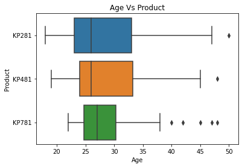

```python
sns.boxplot(data=df,x="Age",y="Product")
plt.title("Age Vs Product")
```

Over a Boxplot of Miles Vs Product we can see outliers for KP281 and KP481 when compared to KP781,which indicates that people who purchase product type of KP281 and KP481 have higher expecations of miles to walk/run per week than reality where as KP781 comparitively meet the expectations.

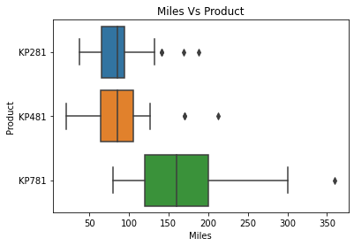

```python
plt.title("Miles Vs Product")
sns.boxplot(data=df,x="Miles",y="Product")
```

Over a Boxplot of Income Vs Product we can see that less outliers lie in the product type KP481 which is both over-rated and under-rated expectations in terms of Annual Income Users.

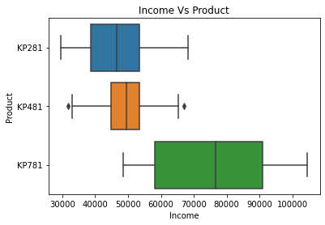

```python
plt.title("Income Vs Product")
sns.boxplot(data=df,x="Income",y="Product")
```

Using describe method(difference between mean and median)

```python
df_des=df.describe(include="all").T[['mean','50%']]
df_des.dropna(inplace=True)
df_des['Outliers']=np.abs(df_des['mean']-df_des['50%'])
```

Here we can determine that a wide range of outliers exist in columns Age,Income,Miles as observed in visual analytics

```python
df_des
```

|  | mean | 50% | Outliers |
| --- | --- | --- | --- |
| Age | 28.788889 | 26.0 | 2.788889 |
| Education | 15.572222 | 16.0 | 0.427778 |
| Usage | 3.455556 | 3.0 | 0.455556 |
| Fitness | 3.311111 | 3.0 | 0.311111 |
| Income | 53719.577778 | 50596.5 | 3123.077778 |
| Miles | 103.194444 | 94.0 | 9.194444 |

### Exploratory Data Analysis

#### UNIVARIANT ANALYSIS

Male column - male have higher rate of purchase of threadmill when compared to female

```python
df["Gender"].value_counts()
```

```
Male      104
Female     76
Name: Gender, dtype: int64
```

Visual Analysis

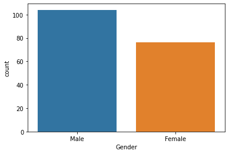

```python
sns.countplot(x=df["Gender"])
```

Visual Analysis

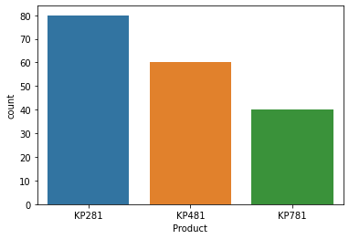

```python
sns.countplot(x=df["Product"])
```

Age column - age group of (20-30) have higher purchase rate of threadmill

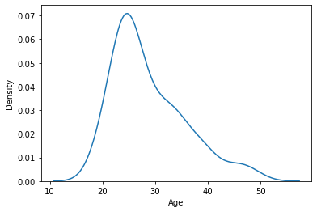

```python
sns.kdeplot(x=df["Age"])
```

Education column - Students of 16 and 14 show high purchase rate when compared to others

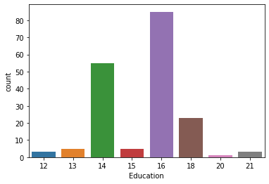

```python
sns.countplot(x=df["Education"])
```

MaritalStatus column - Representing single or partnered shows that partnered show high purchase rate compared to Single

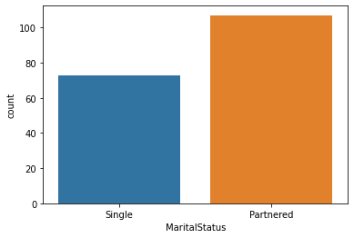

```python
sns.countplot(x=df["MaritalStatus"])
```

Usage column - Represents that on an average over (3-4) times the customer plans to use the treadmill each week.

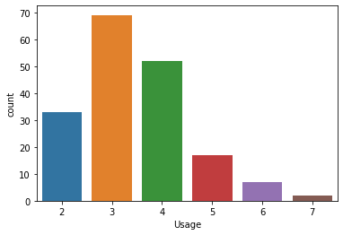

```python
sns.countplot(x=df["Usage"])
```

Fitness column - Self rated fitness on a 1-to-5 scale, where 1 is the poor shape and 5 is the excellent shape,the fitness rated around (2.3 - 3.7) are higher in number

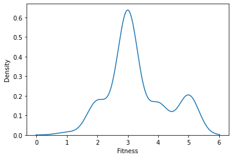

```python
sns.kdeplot(x=df["Fitness"])
```

Income column - Annual income ranges around (25000 - 70000)approx. shows higher purchase rate of threadmill

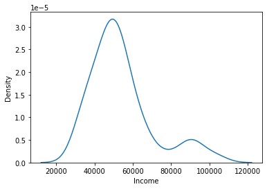

```python
sns.kdeplot(x=df["Income"])
```

Miles column - The average number of miles the customer expects to walk/run each week is more around (0 to 150) miles

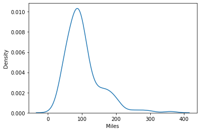

```python
sns.kdeplot(x=df["Miles"])
```

### Comparison of each feature with the target variable

### BIVARIANT ANALYSIS

#### Check if features like marital status, age have any effect on the product purchased

```python
df.columns
```

```
Index(['Product', 'Age', 'Gender', 'Education', 'MaritalStatus', 'Usage',
       'Fitness', 'Income', 'Miles'],
      dtype='object')
```

### Product Vs Gender

Over all the products of threadmill the KP281 is the type where both male and female show purchase rate in using and male show less purchase rate in using KP481 and female show very less interest in using KP781

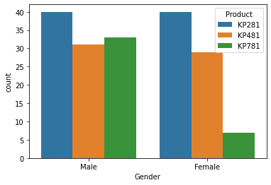

```python
sns.countplot(data=df,x="Gender",hue="Product")
```

### Product Vs Age

Higher rate of ouliers present over KP781 compared to others

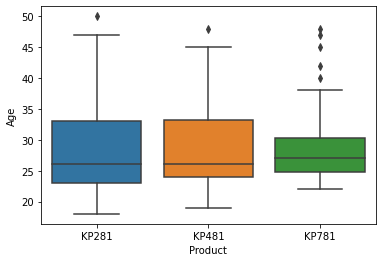

```python
sns.boxplot(data=df,x="Product",y="Age")
```

### Product Vs Education

Students of class 17 show higher purchase rate over KP781 and students of class 15 show higher purchase rate in KP281 and KP481

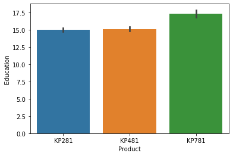

```python
sns.barplot(data=df,x="Product",y="Education")
```

### Product Vs MaritalStatus

Even though Partnered people show higher purchase rate but in both single and partnered people show interest in KP281 product purchase

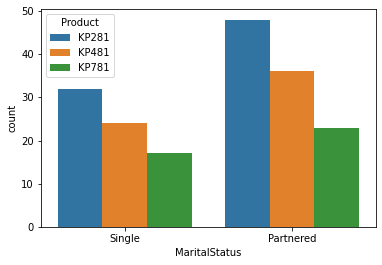

```python
sns.countplot(data=df,hue="Product",x="MaritalStatus")
```

### Product Vs Income

With Annual Income ranging over 20000 to 70000 show higher rate of interest to purchase KP281 and KP481 product type,whereas 50000 to 110000 Annual Income people interest to purchase product type KP781

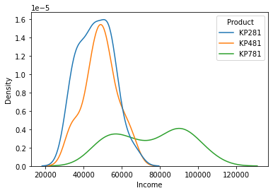

```python
sns.kdeplot(data=df,hue="Product",x="Income")
```

### Product Vs Miles

People who tend to purchase product type of KP281 and KP481 walk/run around 10 to 150 miles each week

People who tend to purchase product type of KP781 walk/run around 100 to 250 miles each week

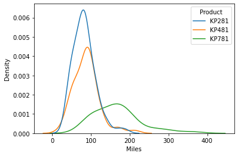

```python
sns.kdeplot(data=df,hue="Product",x="Miles")
```

### Product Vs Fitness

People who use KP281 and KP481 results in fitness level of 3 at max where as people who use KP781 results in fitness level of 5

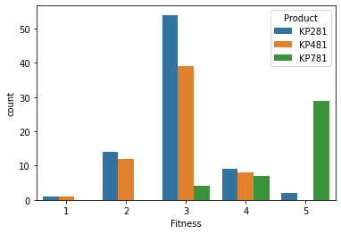

```python
sns.countplot(data=df,hue="Product",x="Fitness")
```

### Product Vs Usage

People who use product of type KP281 and KP481 tend to use threadmill on an average of 2 to 4 times a week where as product type KP781 users tend to use 4 to 6 times on an average over a week

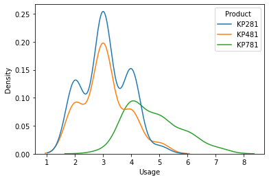

```python
sns.kdeplot(data=df,hue="Product",x="Usage")
```

### MULTIVARIANT ANALYSIS

```python
df.keys()
```

```
Index(['Product', 'Age', 'Gender', 'Education', 'MaritalStatus', 'Usage',
       'Fitness', 'Income', 'Miles'],
      dtype='object')
```

#### Gender Vs Usage Vs Product

Male and Female who purchase KP781 product type on an average uses around 5 times a week

Male and Female who purchase KP281 and KP481 product type on an average uses around 3 to 4 times a week

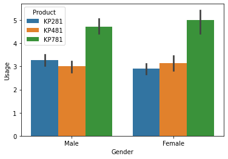

```python
sns.barplot(data=df,x='Gender',y='Usage',hue='Product')
```

### Age Vs Usage Vs Product

People of age (25-35) with using KP781 product type tend to use 4 to 7 times a week with a higher fitness level of 5

People of age (20-40) using product type KP281 and KP481 tend to use 2 to 4 times a week on an average with fitness level of (2-3)

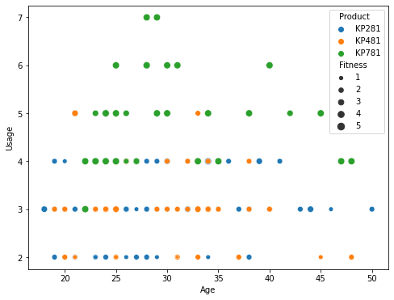

```python
plt.figure(figsize=(8,6))
sns.scatterplot(data=df,x='Age',y='Usage',hue='Product',size='Fitness')
```

### MaritalStatus Vs Usage Vs Product

Both Single and Partnered people use KP781 with higher level of usage over 4 to 5 times a week

Both Single and Partnered people use KP281 and KP481 with level of usage over 3 times a week

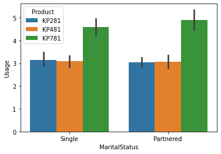

```python
sns.barplot(data=df,x='MaritalStatus',y='Usage',hue='Product')
```

### Income Vs Usage Vs Fitness Vs Product

People of High Income over (60000-110000) tend to purchase KP781 product type with usage of (4-7) times a week on average with high level of fitness(4-5)

People of lower Income over (30000-60000) tend to purchase KP281 and KP481 product type with usage of (2-4) times a week on average with high level of fitness(2-3)

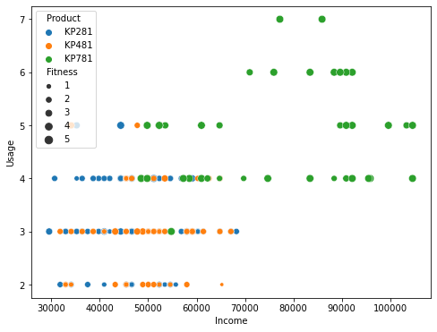

```python
plt.figure(figsize=(8,6))
sns.scatterplot(data=df,x='Income',y='Usage',hue='Product',size='Fitness')
```

### Miles Vs Usage Vs Fitness Vs Product

People who tend to purchase product type KP781 tend to use around (4-7) times a week by running/walking around 150-300 miles in a weeek with a fitness level of (4-5)

People who tend to purchase product type KP281 and KP481 tend to use around (2-4) times a week by running/walking around 50-150 miles in a weeek with a fitness level of (2-3)

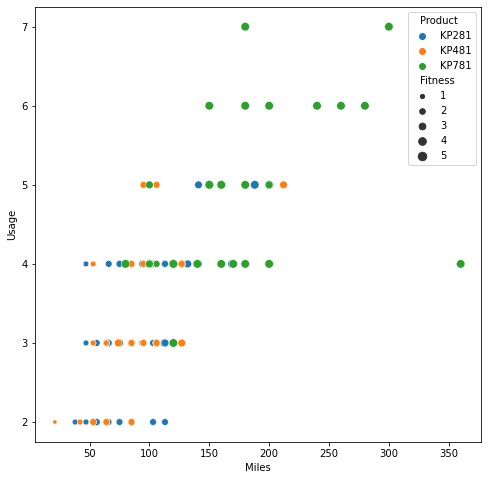

```python
plt.figure(figsize=(8,8))
sns.scatterplot(data=df,x='Miles',y='Usage',hue='Product',size='Fitness')
```

### MARGINAL PROBABILITY

#### 4.Representing the marginal probability like - what percent of customers have purchased KP281, KP481, or KP781 in a table

```python
df.head()
```

|  | Product | Age | Gender | Education | MaritalStatus | Usage | Fitness | Income | Miles |
| --- | --- | --- | --- | --- | --- | --- | --- | --- | --- |
| 0 | KP281 | 18 | Male | 14 | Single | 3 | 4 | 29562 | 112 |
| 1 | KP281 | 19 | Male | 15 | Single | 2 | 3 | 31836 | 75 |
| 2 | KP281 | 19 | Female | 14 | Partnered | 4 | 3 | 30699 | 66 |
| 3 | KP281 | 19 | Male | 12 | Single | 3 | 3 | 32973 | 85 |
| 4 | KP281 | 20 | Male | 13 | Partnered | 4 | 2 | 35247 | 47 |

Around 50% of customers purchases product type KP281 with a fitness level of 1,2,3

Around (40-50)% of customers purchases product type KP481 with a fitness level of 3,2,1

```python
pd.crosstab(df.Fitness,df.Product).apply(lambda r:r/r.sum()*100,axis=1)
```

| Product Fitness | KP281 | KP481 | KP781 |
| --- | --- | --- | --- |
| 1 | 50.000000 | 50.000000 | 0.000000 |
| 2 | 53.846154 | 46.153846 | 0.000000 |
| 3 | 55.670103 | 40.206186 | 4.123711 |
| 4 | 37.500000 | 33.333333 | 29.166667 |
| 5 | 6.451613 | 0.000000 | 93.548387 |

Female: 52% use KP281 product type

```
38% use KP481 product type

9% use KP781 product type
```

Male: 38% use KP281 product type

```
29% use KP481 product type

31% use KP781 product type
```

```python
pd.crosstab(df.Gender,df.Product).apply(lambda r:r/r.sum()*100,axis=1)
```

| Product Gender | KP281 | KP481 | KP781 |
| --- | --- | --- | --- |
| Female | 52.631579 | 38.157895 | 9.210526 |
| Male | 38.461538 | 29.807692 | 31.730769 |

Partnered: 44% use KP281 product type

```
33% use KP481 product type

21% use KP781 product type
```

Single: 43% use KP281 product type

```
32% use KP481 product type

23% use KP781 product type
```

```python
pd.crosstab(df.MaritalStatus,df.Product).apply(lambda r:r/r.sum()*100,axis=1)
```

| Product MaritalStatus | KP281 | KP481 | KP781 |
| --- | --- | --- | --- |
| Partnered | 44.859813 | 33.644860 | 21.495327 |
| Single | 43.835616 | 32.876712 | 23.287671 |

lower class (Class 12 to class 16) Educated customers tend to use KP281 and KP481

Higher class (Class 18 to class 21) Educated customers tend to use KP781

```python
pd.crosstab(df.Education,df.Product).apply(lambda r:r/r.sum()*100,axis=1)
```

| Product Education | KP281 | KP481 | KP781 |
| --- | --- | --- | --- |
| 12 | 66.666667 | 33.333333 | 0.000000 |
| 13 | 60.000000 | 40.000000 | 0.000000 |
| 14 | 54.545455 | 41.818182 | 3.636364 |
| 15 | 80.000000 | 20.000000 | 0.000000 |
| 16 | 45.882353 | 36.470588 | 17.647059 |
| 18 | 8.695652 | 8.695652 | 82.608696 |
| 20 | 0.000000 | 0.000000 | 100.000000 |
| 21 | 0.000000 | 0.000000 | 100.000000 |

KP281 product type purchased consumers tend to use it on an average of 2-4 times a week

KP481 product type purchased consumers tend to use it on an average of 2-4 times a week

KP781 product type purchased consumers tend to use it on an average of 5-7 times a week

```python
pd.crosstab(df.Usage,df.Product).apply(lambda r:r/r.sum()*100,axis=1)
```

| Product Usage | KP281 | KP481 | KP781 |
| --- | --- | --- | --- |
| 2 | 57.575758 | 42.424242 | 0.000000 |
| 3 | 53.623188 | 44.927536 | 1.449275 |
| 4 | 42.307692 | 23.076923 | 34.615385 |
| 5 | 11.764706 | 17.647059 | 70.588235 |
| 6 | 0.000000 | 0.000000 | 100.000000 |
| 7 | 0.000000 | 0.000000 | 100.000000 |

### Bivariant Analysis

Product Type KP281 and KP481 is used by customers whose eduction level around class 14 and class 16 Product Type KP781 is used by customers whose eduction level is higher

Fitness level increases as education increases around from class 15

```python
pd.crosstab([df.Education,df.Fitness],df.Product,margins=True)
```

| Education | Product Fitness | KP281 | KP481 | KP781 | All |
| --- | --- | --- | --- | --- | --- |
| 12 | 2 | 0 | 1 | 0 | 1 |
|  | 3 | 2 | 0 | 0 | 2 |
| 13 | 2 | 2 | 0 | 0 | 2 |
|  | 3 | 1 | 1 | 0 | 2 |
|  | 4 | 0 | 1 | 0 | 1 |
| 14 | 2 | 6 | 5 | 0 | 11 |
|  | 3 | 20 | 14 | 1 | 35 |
|  | 4 | 4 | 4 | 0 | 8 |
|  | 5 | 0 | 0 | 1 | 1 |
| 15 | 2 | 1 | 0 | 0 | 1 |
|  | 3 | 2 | 1 | 0 | 3 |
|  | 4 | 1 | 0 | 0 | 1 |
| 16 | 1 | 1 | 0 | 0 | 1 |
|  | 2 | 5 | 6 | 0 | 11 |
|  | 3 | 27 | 23 | 0 | 50 |
|  | 4 | 4 | 2 | 2 | 8 |
|  | 5 | 2 | 0 | 13 | 15 |
| 18 | 1 | 0 | 1 | 0 | 1 |
|  | 3 | 2 | 0 | 2 | 4 |
|  | 4 | 0 | 1 | 4 | 5 |
|  | 5 | 0 | 0 | 13 | 13 |
| 20 | 5 | 0 | 0 | 1 | 1 |
| 21 | 3 | 0 | 0 | 1 | 1 |
|  | 4 | 0 | 0 | 1 | 1 |
|  | 5 | 0 | 0 | 1 | 1 |
| All |  | 80 | 60 | 40 | 180 |

## Multivariant Analysis

```python
pd.crosstab([df.Education,df.Fitness,df.Usage],df.Product,margins=True)
```

| Education | Fitness | Product Usage | KP281 | KP481 | KP781 | All |
| --- | --- | --- | --- | --- | --- | --- |
| 12 | 2 | 2 | 0 | 1 | 0 | 1 |
|  | 3 | 3 | 1 | 0 | 0 | 1 |
|  |  | 4 | 1 | 0 | 0 | 1 |
| 13 | 2 | 3 | 1 | 0 | 0 | 1 |
|  |  | 4 | 1 | 0 | 0 | 1 |
|  | 3 | 3 | 1 | 0 | 0 | 1 |
|  |  | 4 | 0 | 1 | 0 | 1 |
|  | 4 | 4 | 0 | 1 | 0 | 1 |
| 14 | 2 | 2 | 4 | 1 | 0 | 5 |
|  |  | 3 | 2 | 3 | 0 | 5 |
|  |  | 4 | 0 | 1 | 0 | 1 |
|  | 3 | 2 | 7 | 3 | 0 | 10 |
|  |  | 3 | 9 | 8 | 0 | 17 |
|  |  | 4 | 4 | 2 | 1 | 7 |
|  |  | 5 | 0 | 1 | 0 | 1 |
|  | 4 | 3 | 3 | 3 | 0 | 6 |
|  |  | 4 | 1 | 0 | 0 | 1 |
|  |  | 5 | 0 | 1 | 0 | 1 |
|  | 5 | 7 | 0 | 0 | 1 | 1 |
| 15 | 2 | 2 | 1 | 0 | 0 | 1 |
|  | 3 | 2 | 2 | 0 | 0 | 2 |
|  |  | 3 | 0 | 1 | 0 | 1 |
|  | 4 | 5 | 1 | 0 | 0 | 1 |
| 16 | 1 | 3 | 1 | 0 | 0 | 1 |
|  | 2 | 2 | 4 | 3 | 0 | 7 |
|  |  | 3 | 1 | 3 | 0 | 4 |
|  | 3 | 2 | 1 | 5 | 0 | 6 |
|  |  | 3 | 14 | 11 | 0 | 25 |
|  |  | 4 | 12 | 6 | 0 | 18 |
|  |  | 5 | 0 | 1 | 0 | 1 |
|  | 4 | 3 | 2 | 1 | 0 | 3 |
|  |  | 4 | 2 | 1 | 1 | 4 |
|  |  | 5 | 0 | 0 | 1 | 1 |
|  | 5 | 3 | 0 | 0 | 1 | 1 |
|  |  | 4 | 1 | 0 | 6 | 7 |
|  |  | 5 | 1 | 0 | 4 | 5 |
|  |  | 6 | 0 | 0 | 2 | 2 |
| 18 | 1 | 2 | 0 | 1 | 0 | 1 |
|  | 3 | 3 | 2 | 0 | 0 | 2 |
|  |  | 4 | 0 | 0 | 2 | 2 |
|  | 4 | 3 | 0 | 1 | 0 | 1 |
|  |  | 5 | 0 | 0 | 3 | 3 |
|  |  | 6 | 0 | 0 | 1 | 1 |
|  | 5 | 4 | 0 | 0 | 5 | 5 |
|  |  | 5 | 0 | 0 | 4 | 4 |
|  |  | 6 | 0 | 0 | 3 | 3 |
|  |  | 7 | 0 | 0 | 1 | 1 |
| 20 | 5 | 4 | 0 | 0 | 1 | 1 |
| 21 | 3 | 4 | 0 | 0 | 1 | 1 |
|  | 4 | 4 | 0 | 0 | 1 | 1 |
|  | 5 | 6 | 0 | 0 | 1 | 1 |
| All |  |  | 80 | 60 | 40 | 180 |

### 5.CORRELATION

#### Check correlation among different factors using heat maps or pair plots.

Heatmaps

```python
df1=df[["Age","Fitness","Usage"]]
```

```python
df1
```

|  | Age | Fitness | Usage |
| --- | --- | --- | --- |
| 0 | 18 | 4 | 3 |
| 1 | 19 | 3 | 2 |
| 2 | 19 | 3 | 4 |
| 3 | 19 | 3 | 3 |
| 4 | 20 | 2 | 4 |
| ... | ... | ... | ... |
| 175 | 40 | 5 | 6 |
| 176 | 42 | 4 | 5 |
| 177 | 45 | 5 | 5 |
| 178 | 47 | 5 | 4 |
| 179 | 48 | 5 | 4 |

180 rows × 3 columns

```python
corr1=df1.corr()
```

Heatmap over factors Age,Fitness,Usage indicates that

Usage and Fitness: Usage and Fitness have positive correlation such that as usage increase the fitness of the person also increases

Age and Fitness,Usage: Age and Fitness,Usage have weakly positive correlated since upto some age as age increases fitness increases due to high usage after that as age increases fitness drastically decreases due to decrease in usage and ability

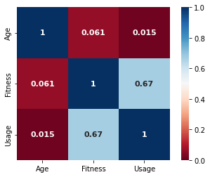

```python
sns.heatmap(corr1,cmap='RdBu',vmin=0,vmax=1,annot=True,annot_kws={'fontsize':11,'fontweight':'bold'},square=True)
```

```python
df2=df[["Miles","Fitness","Usage"]]
```

```python
corr2=df2.corr()
```

Heatmap over Factors Usage,Fitness,Miles

Usage-Miles: Here we can see that a positive correlation betweem them with a correlation value of 0.76 which indicates that as usage increases number of miles walk/run per week also increases

Miles-Fitness: Here we can see that a positive correlation betweem them with a correlation value of 0.79 which indicates that as number of miles walk/run per week increases Fitness also increases

Usage-Fitness: Here we can see that a positive correlation betweem them with a correlation value of 0.67 which indicates that as Usage increases Fitness also increases

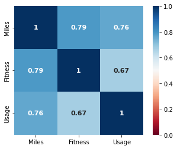

```python
sns.heatmap(corr2,cmap='RdBu',vmin=0,vmax=1,annot=True,annot_kws={'fontsize':11,'fontweight':'bold'},square=True)
```

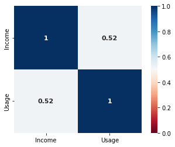

```python
df3=df[["Income","Usage"]]
corr3=df3.corr()
sns.heatmap(corr3,cmap='RdBu',vmin=0,vmax=1,annot=True,annot_kws={'fontsize':11,'fontweight':'bold'},square=True)
```

Correlation heatmap with all factors

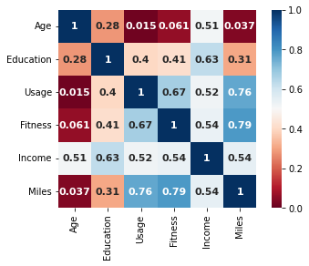

```python
corr=df.corr()
sns.heatmap(corr,cmap='RdBu',vmin=0,vmax=1,annot=True,annot_kws={'fontsize':11,'fontweight':'bold'},square=True)
```

### Pairplot

Here we can see that Fitness and miles of higher level is observed with customers using KP781 and average fitness and miles are obtained using KP281 and KP481

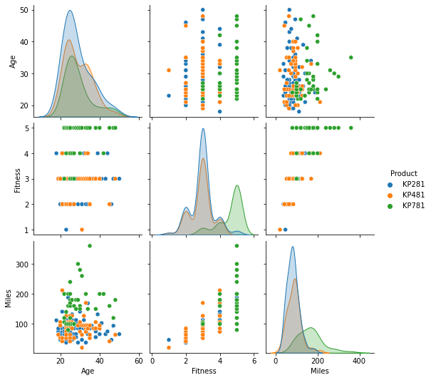

```python
sns.pairplot(df,diag_kind="kde",hue='Product',vars=['Age','Fitness','Miles'])
```

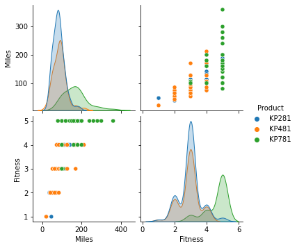

```python
sns.pairplot(df,diag_kind="kde",hue='Product',vars=['Miles','Fitness'])
```

Usage is more for customers with higher level of education

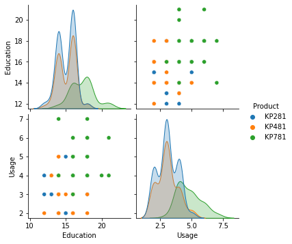

```python
sns.pairplot(df,diag_kind="kde",hue='Product',vars=['Education','Usage'])
```

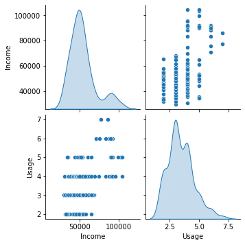

```python
sns.pairplot(df3,diag_kind="kde")
```

### 8.PROBABILITY

### MARGINAL PROBABILITY

#### Marginal Probability Over Fitness

From this we can say that for the product KP281 has fitness ranging 3,2,1 mostly.

From this we can say that for the product KP481 has fitness ranging 1,2,3 mostly.

From this we can say that for the product KP781 has fitness ranging 5 mostly.

Thus it can be infered that advanced options included Threadmill(KP781) results in highest fitness rate of 5.

It can be determined that probability of Fitness 5 buying a Threadmill KP781 is 0.93

```python
pd.crosstab(df.Fitness,df.Product,margins=True,normalize='index')
```

| Product Fitness | KP281 | KP481 | KP781 |
| --- | --- | --- | --- |
| 1 | 0.500000 | 0.500000 | 0.000000 |
| 2 | 0.538462 | 0.461538 | 0.000000 |
| 3 | 0.556701 | 0.402062 | 0.041237 |
| 4 | 0.375000 | 0.333333 | 0.291667 |
| 5 | 0.064516 | 0.000000 | 0.935484 |
| All | 0.444444 | 0.333333 | 0.222222 |

#### Marginal Probability Over Usage

The usage of KP281 is more at the level of 2 and 3

The usage of KP481 is more at the level of 2 and 3

The usage of KP781 is more at the level of 5

```python
pd.crosstab(df.Usage,df.Product,margins=True,normalize='index')
```

| Product Usage | KP281 | KP481 | KP781 |
| --- | --- | --- | --- |
| 2 | 0.575758 | 0.424242 | 0.000000 |
| 3 | 0.536232 | 0.449275 | 0.014493 |
| 4 | 0.423077 | 0.230769 | 0.346154 |
| 5 | 0.117647 | 0.176471 | 0.705882 |
| 6 | 0.000000 | 0.000000 | 1.000000 |
| 7 | 0.000000 | 0.000000 | 1.000000 |
| All | 0.444444 | 0.333333 | 0.222222 |

#### 6.Probability of a male customer buying a KP781 treadmill is 0.31

```python
pd.crosstab(df.Gender,df.Product,margins=True,normalize='index')
```

| Product Gender | KP281 | KP481 | KP781 |
| --- | --- | --- | --- |
| Female | 0.526316 | 0.381579 | 0.092105 |
| Male | 0.384615 | 0.298077 | 0.317308 |
| All | 0.444444 | 0.333333 | 0.222222 |

##### Marginal Probility Over Education

```python
pd.crosstab(df.Education,df.Product,margins=True,normalize='index')
```

| Product Education | KP281 | KP481 | KP781 |
| --- | --- | --- | --- |
| 12 | 0.666667 | 0.333333 | 0.000000 |
| 13 | 0.600000 | 0.400000 | 0.000000 |
| 14 | 0.545455 | 0.418182 | 0.036364 |
| 15 | 0.800000 | 0.200000 | 0.000000 |
| 16 | 0.458824 | 0.364706 | 0.176471 |
| 18 | 0.086957 | 0.086957 | 0.826087 |
| 20 | 0.000000 | 0.000000 | 1.000000 |
| 21 | 0.000000 | 0.000000 | 1.000000 |
| All | 0.444444 | 0.333333 | 0.222222 |

### Conditional Probability

#### Conditional Probability Over Fitness

Probability of KP481 given that fitness is 3 (P(KP481/3)) is 0.65 is the highest probability over the product type KP481.

Probability of KP781 given that fitness is 5 (P(KP781/5))=0.7 is the highest probability over the product type KP781.

```python
pd.crosstab(df.Fitness,df.Product,margins=True,normalize='columns')
```

| Product Fitness | KP281 | KP481 | KP781 | All |
| --- | --- | --- | --- | --- |
| 1 | 0.0125 | 0.016667 | 0.000 | 0.011111 |
| 2 | 0.1750 | 0.200000 | 0.000 | 0.144444 |
| 3 | 0.6750 | 0.650000 | 0.100 | 0.538889 |
| 4 | 0.1125 | 0.133333 | 0.175 | 0.133333 |
| 5 | 0.0250 | 0.000000 | 0.725 | 0.172222 |

#### Conditional Probability Over Usage

Probability of user to buy KP281 product type given the the level of usage is 3 is 0.46

Probability of user to buy KP481 product type given the the level of usage is 3 is 0.51

Probability of user to buy KP781 product type given the the level of usage is 4 is 0.45

```python
pd.crosstab(df.Usage,df.Product,margins=True,normalize='columns')
```

| Product Usage | KP281 | KP481 | KP781 | All |
| --- | --- | --- | --- | --- |
| 2 | 0.2375 | 0.233333 | 0.000 | 0.183333 |
| 3 | 0.4625 | 0.516667 | 0.025 | 0.383333 |
| 4 | 0.2750 | 0.200000 | 0.450 | 0.288889 |
| 5 | 0.0250 | 0.050000 | 0.300 | 0.094444 |
| 6 | 0.0000 | 0.000000 | 0.175 | 0.038889 |
| 7 | 0.0000 | 0.000000 | 0.050 | 0.011111 |

###### Conditional Probability Over other columns

```python
pd.crosstab(df.Miles,df.Product,margins=True,normalize='columns')
```

| Product Miles | KP281 | KP481 | KP781 | All |
| --- | --- | --- | --- | --- |
| 21 | 0.0000 | 0.016667 | 0.000 | 0.005556 |
| 38 | 0.0375 | 0.000000 | 0.000 | 0.016667 |
| 42 | 0.0000 | 0.066667 | 0.000 | 0.022222 |
| 47 | 0.1125 | 0.000000 | 0.000 | 0.050000 |
| 53 | 0.0000 | 0.116667 | 0.000 | 0.038889 |
| 56 | 0.0750 | 0.000000 | 0.000 | 0.033333 |
| 64 | 0.0000 | 0.100000 | 0.000 | 0.033333 |
| 66 | 0.1250 | 0.000000 | 0.000 | 0.055556 |
| 74 | 0.0000 | 0.050000 | 0.000 | 0.016667 |
| 75 | 0.1250 | 0.000000 | 0.000 | 0.055556 |
| 80 | 0.0000 | 0.000000 | 0.025 | 0.005556 |
| 85 | 0.2000 | 0.183333 | 0.000 | 0.150000 |
| 94 | 0.1000 | 0.000000 | 0.000 | 0.044444 |
| 95 | 0.0000 | 0.200000 | 0.000 | 0.066667 |
| 100 | 0.0000 | 0.000000 | 0.175 | 0.038889 |
| 103 | 0.0375 | 0.000000 | 0.000 | 0.016667 |
| 106 | 0.0000 | 0.133333 | 0.025 | 0.050000 |
| 112 | 0.0125 | 0.000000 | 0.000 | 0.005556 |
| 113 | 0.1000 | 0.000000 | 0.000 | 0.044444 |
| 120 | 0.0000 | 0.000000 | 0.075 | 0.016667 |
| 127 | 0.0000 | 0.083333 | 0.000 | 0.027778 |
| 132 | 0.0250 | 0.000000 | 0.000 | 0.011111 |
| 140 | 0.0000 | 0.000000 | 0.025 | 0.005556 |
| 141 | 0.0250 | 0.000000 | 0.000 | 0.011111 |
| 150 | 0.0000 | 0.000000 | 0.100 | 0.022222 |
| 160 | 0.0000 | 0.000000 | 0.125 | 0.027778 |
| 169 | 0.0125 | 0.000000 | 0.000 | 0.005556 |
| 170 | 0.0000 | 0.033333 | 0.025 | 0.016667 |
| 180 | 0.0000 | 0.000000 | 0.150 | 0.033333 |
| 188 | 0.0125 | 0.000000 | 0.000 | 0.005556 |
| 200 | 0.0000 | 0.000000 | 0.150 | 0.033333 |
| 212 | 0.0000 | 0.016667 | 0.000 | 0.005556 |
| 240 | 0.0000 | 0.000000 | 0.025 | 0.005556 |
| 260 | 0.0000 | 0.000000 | 0.025 | 0.005556 |
| 280 | 0.0000 | 0.000000 | 0.025 | 0.005556 |
| 300 | 0.0000 | 0.000000 | 0.025 | 0.005556 |
| 360 | 0.0000 | 0.000000 | 0.025 | 0.005556 |

```python
pd.crosstab(df.Income,df.Product,margins=True,normalize='columns')
```

| Product Income | KP281 | KP481 | KP781 | All |
| --- | --- | --- | --- | --- |
| 29562 | 0.0125 | 0.000000 | 0.000 | 0.005556 |
| 30699 | 0.0125 | 0.000000 | 0.000 | 0.005556 |
| 31836 | 0.0125 | 0.016667 | 0.000 | 0.011111 |
| 32973 | 0.0375 | 0.033333 | 0.000 | 0.027778 |
| 34110 | 0.0250 | 0.050000 | 0.000 | 0.027778 |
| ... | ... | ... | ... | ... |
| 95508 | 0.0000 | 0.000000 | 0.025 | 0.005556 |
| 95866 | 0.0000 | 0.000000 | 0.025 | 0.005556 |
| 99601 | 0.0000 | 0.000000 | 0.025 | 0.005556 |
| 103336 | 0.0000 | 0.000000 | 0.025 | 0.005556 |
| 104581 | 0.0000 | 0.000000 | 0.050 | 0.011111 |

62 rows × 4 columns

```python
pd.crosstab(df.Age,df.Product,margins=True,normalize='columns')
```

| Product Age | KP281 | KP481 | KP781 | All |
| --- | --- | --- | --- | --- |
| 18 | 0.0125 | 0.000000 | 0.000 | 0.005556 |
| 19 | 0.0375 | 0.016667 | 0.000 | 0.022222 |
| 20 | 0.0250 | 0.050000 | 0.000 | 0.027778 |
| 21 | 0.0500 | 0.050000 | 0.000 | 0.038889 |
| 22 | 0.0500 | 0.000000 | 0.075 | 0.038889 |
| 23 | 0.1000 | 0.116667 | 0.075 | 0.100000 |
| 24 | 0.0625 | 0.050000 | 0.100 | 0.066667 |
| 25 | 0.0875 | 0.183333 | 0.175 | 0.138889 |
| 26 | 0.0875 | 0.050000 | 0.050 | 0.066667 |
| 27 | 0.0375 | 0.016667 | 0.075 | 0.038889 |
| 28 | 0.0750 | 0.000000 | 0.075 | 0.050000 |
| 29 | 0.0375 | 0.016667 | 0.050 | 0.033333 |
| 30 | 0.0250 | 0.033333 | 0.075 | 0.038889 |
| 31 | 0.0250 | 0.050000 | 0.025 | 0.033333 |
| 32 | 0.0250 | 0.033333 | 0.000 | 0.022222 |
| 33 | 0.0250 | 0.083333 | 0.025 | 0.044444 |
| 34 | 0.0250 | 0.050000 | 0.025 | 0.033333 |
| 35 | 0.0375 | 0.066667 | 0.025 | 0.044444 |
| 36 | 0.0125 | 0.000000 | 0.000 | 0.005556 |
| 37 | 0.0125 | 0.016667 | 0.000 | 0.011111 |
| 38 | 0.0500 | 0.033333 | 0.025 | 0.038889 |
| 39 | 0.0125 | 0.000000 | 0.000 | 0.005556 |
| 40 | 0.0125 | 0.050000 | 0.025 | 0.027778 |
| 41 | 0.0125 | 0.000000 | 0.000 | 0.005556 |
| 42 | 0.0000 | 0.000000 | 0.025 | 0.005556 |
| 43 | 0.0125 | 0.000000 | 0.000 | 0.005556 |
| 44 | 0.0125 | 0.000000 | 0.000 | 0.005556 |
| 45 | 0.0000 | 0.016667 | 0.025 | 0.011111 |
| 46 | 0.0125 | 0.000000 | 0.000 | 0.005556 |
| 47 | 0.0125 | 0.000000 | 0.025 | 0.011111 |
| 48 | 0.0000 | 0.016667 | 0.025 | 0.011111 |
| 50 | 0.0125 | 0.000000 | 0.000 | 0.005556 |

```python
pd.crosstab(df.Education,df.Product,margins=True,normalize='columns')
```

| Product Education | KP281 | KP481 | KP781 | All |
| --- | --- | --- | --- | --- |
| 12 | 0.0250 | 0.016667 | 0.000 | 0.016667 |
| 13 | 0.0375 | 0.033333 | 0.000 | 0.027778 |
| 14 | 0.3750 | 0.383333 | 0.050 | 0.305556 |
| 15 | 0.0500 | 0.016667 | 0.000 | 0.027778 |
| 16 | 0.4875 | 0.516667 | 0.375 | 0.472222 |
| 18 | 0.0250 | 0.033333 | 0.475 | 0.127778 |
| 20 | 0.0000 | 0.000000 | 0.025 | 0.005556 |
| 21 | 0.0000 | 0.000000 | 0.075 | 0.016667 |

```python
pd.crosstab([df.Education,df.Fitness],df.Product,margins=True)
```

| Education | Product Fitness | KP281 | KP481 | KP781 | All |
| --- | --- | --- | --- | --- | --- |
| 12 | 2 | 0 | 1 | 0 | 1 |
|  | 3 | 2 | 0 | 0 | 2 |
| 13 | 2 | 2 | 0 | 0 | 2 |
|  | 3 | 1 | 1 | 0 | 2 |
|  | 4 | 0 | 1 | 0 | 1 |
| 14 | 2 | 6 | 5 | 0 | 11 |
|  | 3 | 20 | 14 | 1 | 35 |
|  | 4 | 4 | 4 | 0 | 8 |
|  | 5 | 0 | 0 | 1 | 1 |
| 15 | 2 | 1 | 0 | 0 | 1 |
|  | 3 | 2 | 1 | 0 | 3 |
|  | 4 | 1 | 0 | 0 | 1 |
| 16 | 1 | 1 | 0 | 0 | 1 |
|  | 2 | 5 | 6 | 0 | 11 |
|  | 3 | 27 | 23 | 0 | 50 |
|  | 4 | 4 | 2 | 2 | 8 |
|  | 5 | 2 | 0 | 13 | 15 |
| 18 | 1 | 0 | 1 | 0 | 1 |
|  | 3 | 2 | 0 | 2 | 4 |
|  | 4 | 0 | 1 | 4 | 5 |
|  | 5 | 0 | 0 | 13 | 13 |
| 20 | 5 | 0 | 0 | 1 | 1 |
| 21 | 3 | 0 | 0 | 1 | 1 |
|  | 4 | 0 | 0 | 1 | 1 |
|  | 5 | 0 | 0 | 1 | 1 |
| All |  | 80 | 60 | 40 | 180 |

### Customer Profiling - Categorization of users.

From above analysis we can determine that

#### Usage-Miles:

Here we can see that a positive correlation betweem them with a correlation value of 0.76 which indicates that as usage increases number of miles walk/run per week also increases

#### Miles-Fitness:

Here we can see that a positive correlation betweem them with a correlation value of 0.79 which indicates that as number of miles walk/run per week increases Fitness also increases

#### Usage-Fitness:

Here we can see that a positive correlation betweem them with a correlation value of 0.67 which indicates that as Usage increases Fitness also increases

#### Age-Fitness:

Age and Fitness have weakly positive correlated since upto some age as age increases fitness increases after that as age increases fitness drastically decreases

#### Age-Usage:

Age and Usage have weakly positive correlated since upto some age as age increases usage increases after that as age increases usage decreases

#### Product-Gender:

Over all the products of threadmill the KP281 is the type where both male and female show purchase rate in using and male show less purchase rate in using KP481 and female show very less interest in using KP781

#### Product-Income:

With Annual Income ranging over 20000 to 70000 show higher rate of interest to purchase KP281 and KP481 product type,whereas 50000 to 110000 Annual Income people interest to purchase product type KP781

#### Product-Usage:

People who use product of type KP281 and KP481 tend to use threadmill on an average of 2 to 4 times a week where as product type KP781 users tend to use 4 to 6 times on an average over a week

#### Product-Fitness:

People who use KP281 and KP481 results in fitness level of 3 at max where as people who use KP781 results in fitness level of 5

#### Product-Education:

Students of class 17 show higher purchase rate over KP781 and students of class 15 show higher purchase rate in KP281 and KP481

#### Product-MaritalStatus:

Even though Partnered people show higher purchase rate but in both single and partnered people show interest in KP281 product purchase

#### Product Vs Miles

People who tend to purchase product type of KP281 and KP481 walk/run around 10 to 150 miles each week. People who tend to purchase product type of KP781 walk/run around 100 to 250 miles each week

### Recommendations and Actionable Insights

KP781 product type of threadmill is recommended to people where

```
 -Age : (25-30)
 -Gender : Male
 -Education : (18-21)
 -MaritalStatus : Partnered
 -Income : higher Annual Income
```

And to people who need results of

```
  -Usage : (4-7)
  -Fitness : 5
  -Miles : (100-250)
```

KP281 product type of threadmill is recommended to people where

```
 -Age : (23-33)
 -Gender : Male/Female
 -Education : (12-16)
 -MaritalStatus : Partnered
 -Income : Medium Annual Income
```

And to people who need results of

```
  -Usage : (2-4)
  -Fitness : 3
  -Miles : (10-140)
```

KP481 product type of threadmill is recommended to people where

```
 -Age : (24-33)
 -Gender : Male
 -Education : (12-16)
 -MaritalStatus : Partnered
 -Income : Medium Annual Income
```

And to people who need results of

```
  -Usage : (2-4)
  -Fitness : 3
  -Miles : (10-150)
```